# Untitled

## Question 5

Explore an interesting question (not covered by the previous questions), and answer the question using the GSS data.

Question: What is the difference between Sex and party affiliation.

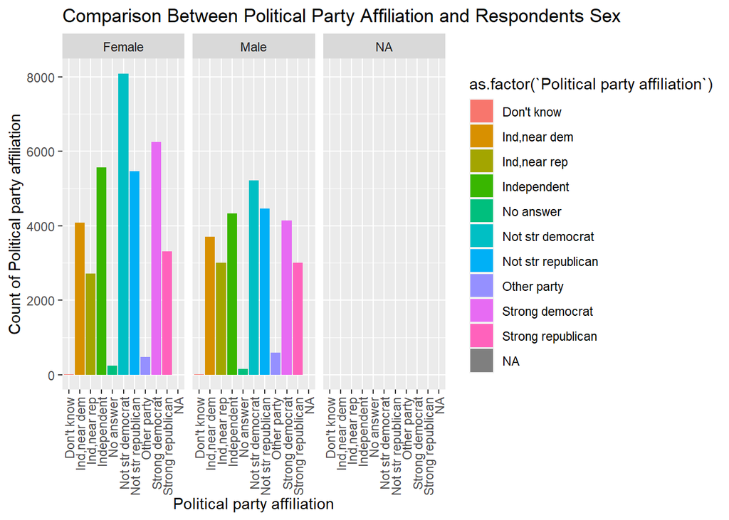

```r
s <- ggplot(data = data1, aes(x = `Political party affiliation`, fill = as.factor(`Political party affiliation`)))+geom_bar()+facet_grid(. ~`Respondents sex`)
s + theme(axis.text.x = element_text(angle = 90, vjust = 0.5, hjust = 1))+ xlab("Political party affiliation")+ylab("Count of Political party affiliation")+ggtitle("Comparison Between Political Party Affiliation and Respondents Sex")
```

```r
table(data1$`Respondents sex`)
```

```
##
## Female   Male
##  36200  28614
```

Response: This visual representation shows the difference between Political Party Affiliation and what Sex they define as. When looking at the general visual representation, you can see that more woman responded to the survey comparative to males. You can see in the numerical analysis that Females out numbered Males by 7,586 people. Another analysis that I am making is when looking at Strong Republican like the last problem stayed similar as well. When looking at the last question as well it was the same, I would like to dive deeper into the data of how that breaks down between the relationship if Male and Female is related to being Happy or Not. Both graphs have semi-normal distribution in the bar plot.